# **Análisis de la distribución geográfica y temporal de la familia Centrolenidae en Costa Rica: Implicaciones para la biodiversidad y conservación**

Elaborado por: Pamela Jiménez Montiel

Descripción del proyecto y justificación

El presente proyecto tiene como finalidad realizar un análisis de la distribución geográfica y temporal de las especies de la familia Centrolenidae (ranas de vidrio) en Costa Rica. Utilizando un conjunto de datos de observaciones de estas especies, se investigarán los patrones de biodiversidad a nivel nacional y se identificarán áreas críticas para la conservación. Este análisis busca proporcionar información útil para la toma de decisiones en la protección de estas especies, ya que muchas de ellas están en peligro debido a la pérdida de hábitat y el cambio climático (Fisher, 2023). Las ranas de vidrio son un grupo ecológicamente importante debido a su sensibilidad a cambios en su entorno, lo que las convierte en excelentes bioindicadores (Romero, 2023). Sin embargo, sus poblaciones han disminuido en los últimos años debido a la destrucción de los bosques tropicales y la contaminación de los cuerpos de agua (Torres, 2019). Este proyecto se justifica por la necesidad urgente de generar información actualizada sobre su distribución y estado de conservación en Costa Rica, un país que alberga una biodiversidad significativa de este grupo. El análisis se basará en técnicas de ciencia de datos, aplicando bibliotecas como Pandas y GeoPandas, para procesar y visualizar los datos, permitiendo una comprensión profunda de los factores que afectan a estas especies. Además, este proyecto busca aportar conocimiento para la planificación de estrategias de conservación basadas en datos, brindando una base científica sólida para la toma de decisiones. Al comprender cómo varía la presencia de las especies de Centrolenidae a lo largo del tiempo y el espacio, se podrán diseñar programas de conservación más efectivos y enfocados en las áreas donde estas especies están en mayor riesgo.

Antecedentes

La familia Centrolenidae, conocidas comúnmente como ranas de cristal, ha sido objeto de investigación en proyectos como el realizado por el Costa Rican Amphibian Research Center, que estudia su distribución, ecología y conservación en Costa Rica. Estas ranas son sensibles a la deforestación y a la contaminación de los cuerpos de agua, lo que las convierte en bioindicadores importantes de la salud ambiental (Torres, 2019). Sin embargo, la falta de información sobre su distribución actual y su estado de conservación representa un obstáculo para el desarrollo de estrategias efectivas de protección.

National Geographic también ha resaltado la importancia de las ranas de cristal, destacando su rol crucial en los ecosistemas tropicales y los esfuerzos de conservación para protegerlas. Por eso Costa Rica, un país reconocido por su rica biodiversidad, es un lugar crítico para la protección de estas especies debido a la amenaza constante de la pérdida de hábitat.

Zhang (2017) resalta la importancia de los macrodatos en la ciencia de la biodiversidad, lo que permite llenar vacíos de información sobre especies en peligro. Herramientas como la ciencia ciudadana, en la que la población participa en la recolección de datos, permiten a los científicos acceder a información valiosa sobre la distribución de especies en tiempo real. Esta metodología ha sido utilizada por Forti y Szabo (2023), quienes analizaron datos de iNaturalist sobre anfibios en Brasil, demostrando que los datos generados por ciudadanos pueden ayudar a responder preguntas clave sobre biodiversidad y conservación.

Estos antecedentes muestran que el uso de datos masivos y herramientas de ciencia de datos puede ser fundamental para mejorar nuestro entendimiento de la distribución de especies como las ranas de cristal en Costa Rica. Al analizar los datos recolectados de múltiples fuentes, incluidos datos de ciencia ciudadana, este proyecto busca aportar información valiosa para la conservación de la familia Centrolenidae en el país, contribuyendo al futuro diseño de políticas de protección más efectivas.

Descripción del problema y objetivo

Las ranas de cristal, pertenecientes a la familia Centrolenidae, son un grupo de anfibios que desempeñan un papel crucial en los ecosistemas tropicales de Costa Rica (Rivera, 2022). Estas especies, conocidas por su piel translúcida, son extremadamente sensibles a cambios en su entorno, lo que las convierte en bioindicadores de la salud ambiental, particularmente en los hábitats acuáticos (Romero, 2023). Sin embargo, a pesar de su importancia ecológica, muchas de las especies de esta familia están bajo amenaza debido a la pérdida de hábitat causada por la deforestación, la expansión agrícola y el cambio climático (Fisher, 2023).

Uno de los principales problemas que enfrenta la conservación de estas especies es la falta de información detallada sobre su distribución actual. Aunque se sabe que habitan en zonas de selva húmeda y montañas, las observaciones históricas y recientes no han sido analizadas de manera exhaustiva, lo que dificulta la identificación de áreas críticas para su conservación. Además, existe incertidumbre sobre la precisión de las observaciones geográficas registradas en las bases de datos de biodiversidad, lo que puede afectar la toma de decisiones para la conservación efectiva de estas especies.

Otro desafío importante es la fragmentación de los ecosistemas donde habitan estas ranas. La creación de corredores biológicos, áreas protegidas y políticas de manejo sostenible dependen de un conocimiento sólido de los patrones de presencia y distribución de las especies, algo que actualmente es limitado debido a la falta de análisis específicos sobre estas poblaciones.

El objetivo del proyecto es analizar la distribución geográfica y temporal de las especies de la familia Centrolenidae en Costa Rica, utilizando observaciones registradas en una base de datos de biodiversidad. A través de este análisis, se busca identificar patrones de presencia, posibles áreas de alta biodiversidad, y evaluar la relación entre las observaciones y la precisión geográfica, con el fin de proponer recomendaciones para la conservación de estas especies en peligro de extinción.

Descripción de los datos

El conjunto de datos utilizado para este proyecto fue obtenido de la plataforma de ciencia ciudadana iNaturalist y contiene registros de observaciones de ranas de la familia Centrolenidae en Costa Rica. Estos registros incluyen una variedad de observaciones realizadas tanto por investigadores como por ciudadanos interesados en contribuir al conocimiento de la biodiversidad.

Este conjunto de datos ofrece una base sólida para identificar patrones de distribución y biodiversidad de las ranas de cristal en Costa Rica, contribuyendo a la formulación de propuestas de conservación.

iNaturalist community. Observaciones de la familia Centrolenidae de Costa Rica. Exportada de https://costarica.inaturalist.org el 27 de setiembre de 2024.

```python
import pandas as pd
# Leemos el archivo CSV en un DataFrame de pandas
df = pd.read_csv('Centrolenidae.csv')

# Información general del DataFrame
info = df.info()
```

```
<class 'pandas.core.frame.DataFrame'>
RangeIndex: 2566 entries, 0 to 2565
Data columns (total 29 columns):
 #   Column                         Non-Null Count  Dtype
---  ------                         --------------  -----
 0   id                             2566 non-null   int64
 1   observed_on_string             2566 non-null   object
 2   time_zone                      2566 non-null   object
 3   user_id                        2566 non-null   int64
 4   user_login                     2566 non-null   object
 5   created_at                     2566 non-null   object
 6   updated_at                     2566 non-null   object
 7   quality_grade                  2566 non-null   object
 8   url                            2566 non-null   object
 9   tag_list                       51 non-null     object
```

[output cut: 21 more lines]

```python
# Aumentar el límite de columnas visibles
pd.set_option('display.max_columns', None)

#Mostrar las primeras 25 filas sin límite en la cantidad de columnas
df.head(25)
```

|  | id | observed_on_string | time_zone | user_id | user_login | created_at | updated_at | quality_grade | url | tag_list | description | num_identification_agreements | captive_cultivated | oauth_application_id | place_guess | latitude | longitude | positional_accuracy | private_place_guess | public_positional_accuracy | geoprivacy | taxon_geoprivacy | coordinates_obscured | positioning_method | species_guess | scientific_name | common_name | iconic_taxon_name | taxon_id |
| --- | --- | --- | --- | --- | --- | --- | --- | --- | --- | --- | --- | --- | --- | --- | --- | --- | --- | --- | --- | --- | --- | --- | --- | --- | --- | --- | --- | --- | --- |
| 0 | 18212 | 2008-05-22 | Eastern Time (US & Canada) | 1325 | jplarry | 2011-05-25 18:32:07 UTC | 2019-09-27 02:32:38 UTC | research | http://www.inaturalist.org/observations/18212 | NaN | Found calling along the river | 2 | False | NaN | Sarapiquí, CR-HE, CR | 10.431200 | -84.005182 | NaN | NaN | NaN | NaN | open | False | NaN | rana de vidrio esmeralda | Espadarana prosoblepon | rana de vidrio esmeralda | Amphibia | 134933 |
| 1 | 18776 | 2009-12-30 | Central America | 486 | nito72 | 2011-05-29 21:29:44 UTC | 2020-01-22 16:52:47 UTC | research | http://www.inaturalist.org/observations/18776 | NaN | This is one of the smaller Costa Rican centron... | 0 | False | NaN | Drake Bay, Costa Rica | 8.688725 | -83.668087 | NaN | NaN | NaN | NaN | open | False | NaN | Reticulated Glass Frog | Hyalinobatrachium valerioi | Ranita de Vidrio | Amphibia | 21323 |
| 2 | 19507 | 2011-05-28 | Central America | 1236 | victoracostachaves | 2011-05-31 16:30:01 UTC | 2024-03-01 13:20:15 UTC | research | http://www.inaturalist.org/observations/19507 | Hyalinobatrachium valerioi | That observation was made near Fila Asunción, ... | 2 | False | NaN | Limón, CR | 9.928597 | -83.062798 | NaN | NaN | 31218.0 | obscured | open | True | NaN | Reticulated Glass Frog | Hyalinobatrachium valerioi | Ranita de Vidrio | Amphibia | 21323 |
| 3 | 22238 | 2011-05-28 | Central America | 1236 | victoracostachaves | 2011-06-19 21:04:42 UTC | 2021-09-23 21:14:14 UTC | research | http://www.inaturalist.org/observations/22238 | Hyalinobatrachium talamancae | Observation made near Fila Matama, Limón by Ví... | 1 | False | NaN | Limón, CR | 9.827665 | -83.032979 | NaN | NaN | 10000.0 | obscured | NaN | True | NaN | Green-striped Glass Frog | Hyalinobatrachium talamancae | NaN | Amphibia | 21357 |
| 4 | 25203 | 3/4/11 | Pacific Time (US & Canada) | 2246 | redpine | 2011-07-17 05:06:16 UTC | 2021-01-23 22:37:31 UTC | research | http://www.inaturalist.org/observations/25203 | NaN | On leaf, near head water of stream in forest.\... | 3 | False | NaN | Wilson Botanical Garden, Coto Brus, Costa Rica | 8.784484 | -82.962227 | NaN | NaN | NaN | NaN | open | False | NaN | rana de vidrio esmeralda | Espadarana prosoblepon | rana de vidrio esmeralda | Amphibia | 134933 |
| 5 | 25303 | 6/18/2011 | Pacific Time (US & Canada) | 2246 | redpine | 2011-07-17 23:34:10 UTC | 2021-05-19 18:20:26 UTC | research | http://www.inaturalist.org/observations/25303 | NaN | Found on coffee bush, in coffee plantation. Ne... | 1 | False | NaN | Coto Brus, Costa Rica | 8.781804 | -82.913046 | NaN | NaN | NaN | NaN | open | False | NaN | Ranita de cristal norteña | Hyalinobatrachium fleischmanni | Ranita de cristal norteña | Amphibia | 21324 |
| 6 | 27295 | 2009-05-15 | Indiana (East) | 2482 | rahunt2 | 2011-08-09 23:51:46 UTC | 2019-09-27 02:32:30 UTC | research | http://www.inaturalist.org/observations/27295 | NaN | NaN | 2 | False | NaN | Monte Verde, Costa Rica | 10.306982 | -84.809731 | NaN | NaN | NaN | NaN | open | False | NaN | rana de vidrio esmeralda | Espadarana prosoblepon | rana de vidrio esmeralda | Amphibia | 134933 |
| 7 | 27297 | 2009-05-15 | Indiana (East) | 2482 | rahunt2 | 2011-08-09 23:53:28 UTC | 2024-03-06 12:40:14 UTC | research | http://www.inaturalist.org/observations/27297 | NaN | NaN | 2 | False | NaN | Tirimbina, Costa Rica | 10.398960 | -84.135063 | NaN | NaN | NaN | NaN | open | False | NaN | Yellow-flecked Glassfrog | Sachatamia albomaculata | Ranita de Vidrio | Amphibia | 21278 |
| 8 | 27299 | 2009-05-15 | Indiana (East) | 2482 | rahunt2 | 2011-08-09 23:57:57 UTC | 2018-09-21 19:41:53 UTC | research | http://www.inaturalist.org/observations/27299 | NaN | NaN | 1 | False | NaN | Monte Verde, Costa Rica | 10.306982 | -84.809731 | NaN | NaN | NaN | NaN | open | False | NaN | Plantation Glass Frog | Hyalinobatrachium colymbiphyllum | rana de vidrio de plantación | Amphibia | 134938 |
| 9 | 53981 | 2010-04-25 | Central America | 1236 | victoracostachaves | 2012-02-27 23:48:53 UTC | 2021-09-23 21:14:14 UTC | needs_id | http://www.inaturalist.org/observations/53981 | Hyalinobatrachium colymbiphyllum | Londres de Quepos | 0 | False | NaN | Quepos, Costa Rica | 9.464287 | -84.060518 | NaN | NaN | NaN | NaN | open | False | NaN | Hyalinobatrachium colymbiphyllum | Hyalinobatrachium colymbiphyllum | rana de vidrio de plantación | Amphibia | 134938 |
| 10 | 53989 | 2011-04-10 | Central America | 1236 | victoracostachaves | 2012-02-28 00:23:39 UTC | 2021-09-24 18:29:25 UTC | research | http://www.inaturalist.org/observations/53989 | Teratohyla pulverata | Costa Rica Amphibian Research Center. With UNA... | 1 | False | NaN | Siquirres, Costa Rica | 10.040529 | -83.544830 | NaN | NaN | NaN | NaN | open | False | NaN | Teratohyla pulverata | Teratohyla pulverata | rana de vidrio de chiriquí | Amphibia | 65192 |
| 11 | 79607 | 2012-05-12 | Central Time (US & Canada) | 6702 | darauz18 | 2012-05-16 19:35:31 UTC | 2021-01-23 22:27:55 UTC | research | http://www.inaturalist.org/observations/79607 | NaN | Hyalinobatrachium talamancae, in the rainfores... | 2 | False | NaN | Veragua Rainforest, Liverpool, Limón, Costa Rica | 10.106439 | -83.507020 | 139109.0 | NaN | 139109.0 | NaN | open | False | NaN | Green-striped Glass Frog | Hyalinobatrachium talamancae | NaN | Amphibia | 21357 |
| 12 | 119122 | May 09, 2008 21:30 | Central America | 1236 | victoracostachaves | 2012-09-04 01:56:00 UTC | 2021-09-23 21:14:14 UTC | research | http://www.inaturalist.org/observations/119122 | Teratohyla spinosa | Guayacán de Siquirres, Limón. 2008 | 1 | False | NaN | Siquirres, Limon, Costa Rica | 10.114893 | -83.524932 | NaN | NaN | NaN | NaN | open | False | NaN | Rana de cristal de Espinosa | Teratohyla spinosa | Rana de cristal de Espinosa | Amphibia | 21279 |
| 13 | 119124 | 2011-06-26 | Central America | 1236 | victoracostachaves | 2012-09-04 02:00:47 UTC | 2021-09-23 21:14:14 UTC | research | http://www.inaturalist.org/observations/119124 | Cochranella granulosa | NaN | 1 | False | NaN | Osa Penninsula | 8.429582 | -83.384232 | NaN | NaN | NaN | NaN | NaN | False | NaN | Cochranella granulosa | Cochranella granulosa | rana de vidrio granulosa | Amphibia | 21277 |
| 14 | 120086 | 2011-10-26 | Eastern Time (US & Canada) | 2856 | asydabass | 2012-09-07 01:46:50 UTC | 2019-12-03 17:10:15 UTC | research | http://www.inaturalist.org/observations/120086 | NaN | NaN | 2 | False | NaN | Rara Avis, Las Horquetas, Heredia, Costa Rica | 10.281990 | -84.044871 | NaN | NaN | NaN | NaN | open | False | NaN | Ghost Glass Frog | Sachatamia ilex | Rana de cristal limón | Amphibia | 21307 |
| 15 | 123906 | 2012-08-23 | Eastern Time (US & Canada) | 2856 | asydabass | 2012-09-17 02:03:59 UTC | 2019-06-10 07:45:18 UTC | research | http://www.inaturalist.org/observations/123906 | Sachatamia albomaculata, yellow flecked glassf... | Eggs, approx. 18 hours after being deposited | 1 | False | NaN | Tropical Station La Gamba, La Gamba, Costa Rica | 8.703423 | -83.187546 | 2144.0 | NaN | 2144.0 | NaN | open | False | NaN | Sachatamia albomaculata | Sachatamia albomaculata | Ranita de Vidrio | Amphibia | 21278 |
| 16 | 123941 | 2007-01-04 | Central Time (US & Canada) | 9531 | kucycads | 2012-09-17 02:55:58 UTC | 2021-05-19 18:24:06 UTC | needs_id | http://www.inaturalist.org/observations/123941 | NaN | Found near stream in forest at night | 3 | False | NaN | Bijagual Ecological Reserve, Costa Rica | 10.379174 | -84.110749 | NaN | NaN | NaN | NaN | open | False | NaN | glass frogs | Centrolenidae | Ranas de cristal | Amphibia | 21218 |
| 17 | 131049 | sáb oct 06 2012 19:15:13 GMT-0600 (CST) | Central Time (US & Canada) | 2535 | jeisson | 2012-10-07 01:38:52 UTC | 2021-05-28 16:37:42 UTC | research | http://www.inaturalist.org/observations/131049 | NaN | NaN | 2 | False | NaN | Autopista 237, Coto Brus | 8.785372 | -82.959524 | 247.0 | NaN | 247.0 | NaN | open | False | NaN | Espadarana prosoblepon | Espadarana prosoblepon | rana de vidrio esmeralda | Amphibia | 134933 |
| 18 | 132246 | 2012-04-17 | Amsterdam | 6675 | torwart | 2012-10-08 17:13:01 UTC | 2019-09-27 02:32:11 UTC | research | http://www.inaturalist.org/observations/132246 | NaN | NaN | 1 | False | NaN | bahia drake | 8.688725 | -83.668087 | 1336.0 | NaN | 1336.0 | NaN | open | False | NaN | rana de vidrio esmeralda | Espadarana prosoblepon | rana de vidrio esmeralda | Amphibia | 134933 |
| 19 | 132253 | 2012-04-17 | Amsterdam | 6675 | torwart | 2012-10-08 17:13:02 UTC | 2024-03-06 12:40:11 UTC | research | http://www.inaturalist.org/observations/132253 | NaN | NaN | 2 | False | NaN | bahia drake | 8.688725 | -83.668087 | 1336.0 | NaN | 1336.0 | NaN | open | False | NaN | Yellow-flecked Glassfrog | Sachatamia albomaculata | Ranita de Vidrio | Amphibia | 21278 |
| 20 | 132254 | 2012-04-17 | Amsterdam | 6675 | torwart | 2012-10-08 17:13:03 UTC | 2021-05-20 11:58:41 UTC | research | http://www.inaturalist.org/observations/132254 | NaN | NaN | 2 | False | NaN | bahia drake | 8.688725 | -83.668087 | 1336.0 | NaN | 1336.0 | NaN | open | False | NaN | Emerald Glass Frog | Espadarana prosoblepon | rana de vidrio esmeralda | Amphibia | 134933 |
| 21 | 139203 | 2012-08-19 | Eastern Time (US & Canada) | 2856 | asydabass | 2012-10-25 16:43:10 UTC | 2018-10-06 00:27:41 UTC | research | http://www.inaturalist.org/observations/139203 | Hyalinobatrachium pulveratum, podwered glassfo... | NaN | 1 | False | NaN | Tropical Station La Gamba, La Gamba, Costa Rica | 8.703423 | -83.187546 | 2144.0 | NaN | 2144.0 | NaN | NaN | False | NaN | Chiriquí Glass Frog | Teratohyla pulverata | rana de vidrio de chiriquí | Amphibia | 65192 |
| 22 | 139205 | 2012-08-19 | Eastern Time (US & Canada) | 2856 | asydabass | 2012-10-25 16:47:52 UTC | 2020-07-20 07:12:53 UTC | research | http://www.inaturalist.org/observations/139205 | Cochranella spinosa, Teratohyla spinosa, spine... | NaN | 1 | False | NaN | Rara Avis, Las Horquetas, Heredia, Costa Rica | 10.281674 | -84.045249 | NaN | NaN | NaN | NaN | open | False | NaN | Teratohyla spinosa | Teratohyla spinosa | Rana de cristal de Espinosa | Amphibia | 21279 |
| 23 | 140321 | 2011-08-17 | Eastern Time (US & Canada) | 2856 | asydabass | 2012-10-28 17:24:55 UTC | 2014-06-30 07:51:25 UTC | needs_id | http://www.inaturalist.org/observations/140321 | Hyalinobatrachium pulveratum, Teratohyla pulve... | Teratohyla pulverata eggs, <5 hours | 0 | False | NaN | Osa Peninsula, Costa Rica | 8.565403 | -83.516068 | 36684.0 | NaN | 36684.0 | NaN | NaN | False | NaN | Chiriqui Glass Frog | Teratohyla pulverata | rana de vidrio de chiriquí | Amphibia | 65192 |
| 24 | 140324 | 2011-08-25 | Eastern Time (US & Canada) | 2856 | asydabass | 2012-10-28 17:28:21 UTC | 2024-03-01 13:20:12 UTC | research | http://www.inaturalist.org/observations/140324 | Hyalinobatrachium valerioi, reticulated glassf... | Adult male guarding single egg clutch | 2 | False | NaN | Tropical Station La Gamba, La Gamba, Costa Rica | 8.703423 | -83.187546 | 2144.0 | NaN | 2144.0 | NaN | open | False | NaN | Hyalinobatrachium valerioi | Hyalinobatrachium valerioi | Ranita de Vidrio | Amphibia | 21323 |

```python
# Aumentar el límite de columnas visibles
pd.set_option('display.max_columns', None)

# Mostrar las últimas 25 filas del DataFrame
df.tail(25)
```

|  | id | observed_on_string | time_zone | user_id | user_login | created_at | updated_at | quality_grade | url | tag_list | description | num_identification_agreements | captive_cultivated | oauth_application_id | place_guess | latitude | longitude | positional_accuracy | private_place_guess | public_positional_accuracy | geoprivacy | taxon_geoprivacy | coordinates_obscured | positioning_method | species_guess | scientific_name | common_name | iconic_taxon_name | taxon_id |
| --- | --- | --- | --- | --- | --- | --- | --- | --- | --- | --- | --- | --- | --- | --- | --- | --- | --- | --- | --- | --- | --- | --- | --- | --- | --- | --- | --- | --- | --- |
| 2541 | 242667548 | 2024-09-18 20:56:28 | America/Costa_Rica | 5472344 | mckenzie73 | 2024-09-19 12:52:55 UTC | 2024-09-19 12:58:15 UTC | research | https://www.inaturalist.org/observations/24266... | NaN | NaN | 1 | False | 2.0 | Kekoldi | 9.632434 | -82.780522 | 210.0 | NaN | 210.0 | NaN | open | False | gps | Emerald Glass Frog | Espadarana prosoblepon | rana de vidrio esmeralda | Amphibia | 134933 |
| 2542 | 242667628 | 2024-09-18 20:58:41 | America/Costa_Rica | 5472344 | mckenzie73 | 2024-09-19 12:53:33 UTC | 2024-09-19 12:54:34 UTC | needs_id | https://www.inaturalist.org/observations/24266... | NaN | NaN | 0 | False | 2.0 | Kekoldi | 9.632434 | -82.780522 | 210.0 | NaN | 210.0 | NaN | open | False | gps | Granular Glass Frog | Cochranella granulosa | rana de vidrio granulosa | Amphibia | 21277 |
| 2543 | 242747414 | 2011/01/04 7:03 AM | America/Costa_Rica | 6542923 | fabs1009 | 2024-09-19 20:52:22 UTC | 2024-09-19 20:52:22 UTC | needs_id | https://www.inaturalist.org/observations/24274... | NaN | NaN | 0 | False | NaN | Provincia de Puntarenas, Río Claro, Costa Rica | 8.676903 | -83.065668 | 1800.0 | NaN | 1800.0 | NaN | open | False | NaN | Rana de Vidrio Esmeralda | Espadarana prosoblepon | rana de vidrio esmeralda | Amphibia | 134933 |
| 2544 | 242786222 | 2022-12-10 16:12:00 | America/Costa_Rica | 7717729 | djs39 | 2024-09-20 01:39:05 UTC | 2024-09-20 01:41:22 UTC | needs_id | https://www.inaturalist.org/observations/24278... | NaN | It appears to be a clear substance containing ... | 0 | False | 2.0 | 500 east of the Central Park, La Fortuna, Alaj... | 10.470090 | -84.652959 | 198.0 | NaN | 198.0 | NaN | NaN | False | NaN | Cochranella | Cochranella | NaN | Amphibia | 21219 |
| 2545 | 242797924 | 2024-09-19 21:16:41-06:00 | America/Costa_Rica | 8191732 | jose_montero | 2024-09-20 03:16:48 UTC | 2024-09-20 03:16:57 UTC | needs_id | https://www.inaturalist.org/observations/24279... | NaN | NaN | 0 | False | 3.0 | Calle La Chanchera, San José, San José, CR | 9.982133 | -84.041381 | 4.0 | NaN | 4.0 | NaN | NaN | False | NaN | NaN | Hyalinobatrachium | Ranas de cristal | Amphibia | 21321 |
| 2546 | 242937400 | 2024-06-15 19:52:09-06:00 | America/Costa_Rica | 6244820 | smalo44 | 2024-09-20 19:46:05 UTC | 2024-09-20 19:46:10 UTC | needs_id | https://www.inaturalist.org/observations/24293... | NaN | NaN | 0 | False | 3.0 | Osa, Puntarenas, CR | 8.688987 | -83.659317 | 11.0 | NaN | 11.0 | NaN | open | False | NaN | NaN | Hyalinobatrachium valerioi | Ranita de Vidrio | Amphibia | 21323 |
| 2547 | 242995458 | 2024/09/08 8:29 PM | America/Costa_Rica | 2595369 | bagous | 2024-09-21 02:08:46 UTC | 2024-09-21 02:08:46 UTC | needs_id | https://www.inaturalist.org/observations/24299... | NaN | Along the river at La Gamba | 0 | False | NaN | Provincia de Puntarenas, Golfito, Costa Rica | 8.700473 | -83.201656 | 54.0 | NaN | 54.0 | NaN | open | False | NaN | Hyalinobatrachium valerioi | Hyalinobatrachium valerioi | Ranita de Vidrio | Amphibia | 21323 |
| 2548 | 243003827 | 2024/09/05 10:03 PM | America/Costa_Rica | 2595369 | bagous | 2024-09-21 03:17:59 UTC | 2024-09-21 03:27:58 UTC | needs_id | https://www.inaturalist.org/observations/24300... | NaN | along the river | 1 | False | NaN | Field Station La Gamba, C. La Gamba, Provincia... | 8.701037 | -83.201572 | 269.0 | NaN | 269.0 | NaN | open | False | NaN | Reticulated Glass Frog | Hyalinobatrachium valerioi | Ranita de Vidrio | Amphibia | 21323 |
| 2549 | 243003828 | 2024/09/05 10:01 PM | America/Costa_Rica | 2595369 | bagous | 2024-09-21 03:17:59 UTC | 2024-09-21 03:27:09 UTC | needs_id | https://www.inaturalist.org/observations/24300... | NaN | along the river | 1 | False | NaN | Field Station La Gamba, C. La Gamba, Provincia... | 8.701037 | -83.201572 | 269.0 | NaN | 269.0 | NaN | open | False | NaN | Fleischmann's Glass Frog | Hyalinobatrachium fleischmanni | Ranita de cristal norteña | Amphibia | 21324 |
| 2550 | 243171776 | 2024/09/05 7:27 PM | America/Costa_Rica | 924314 | jacksonfrost | 2024-09-21 20:01:11 UTC | 2024-09-21 20:01:11 UTC | needs_id | https://www.inaturalist.org/observations/24317... | NaN | NaN | 0 | False | NaN | Provincia de Puntarenas, Puerto Jiménez, Costa... | 8.524903 | -83.416968 | 887.0 | NaN | 887.0 | NaN | open | False | NaN | Hyalinobatrachium valerioi | Hyalinobatrachium valerioi | Ranita de Vidrio | Amphibia | 21323 |
| 2551 | 243171782 | 2024/09/05 7:31 PM | America/Costa_Rica | 924314 | jacksonfrost | 2024-09-21 20:01:12 UTC | 2024-09-21 20:01:12 UTC | needs_id | https://www.inaturalist.org/observations/24317... | NaN | NaN | 0 | False | NaN | Provincia de Puntarenas, Puerto Jiménez, Costa... | 8.524903 | -83.416968 | 887.0 | NaN | 887.0 | NaN | open | False | NaN | Hyalinobatrachium valerioi | Hyalinobatrachium valerioi | Ranita de Vidrio | Amphibia | 21323 |
| 2552 | 243171812 | 2024/09/05 8:30 PM | America/Costa_Rica | 924314 | jacksonfrost | 2024-09-21 20:01:20 UTC | 2024-09-21 20:01:20 UTC | needs_id | https://www.inaturalist.org/observations/24317... | NaN | NaN | 0 | False | NaN | Provincia de Puntarenas, Puerto Jiménez, Costa... | 8.524903 | -83.416968 | 887.0 | NaN | 887.0 | NaN | open | False | NaN | Cochranella granulosa | Cochranella granulosa | rana de vidrio granulosa | Amphibia | 21277 |
| 2553 | 243174279 | 2024/09/05 9:17 PM | America/Costa_Rica | 924314 | jacksonfrost | 2024-09-21 20:13:26 UTC | 2024-09-21 20:13:26 UTC | needs_id | https://www.inaturalist.org/observations/24317... | NaN | NaN | 0 | False | NaN | Provincia de Puntarenas, Puerto Jiménez, Costa... | 8.524903 | -83.416968 | 887.0 | NaN | 887.0 | NaN | open | False | NaN | Hyalinobatrachium valerioi | Hyalinobatrachium valerioi | Ranita de Vidrio | Amphibia | 21323 |
| 2554 | 243290568 | 2022/10/15 03:42 | America/Costa_Rica | 2791171 | adrianpuntschart | 2024-09-22 09:15:19 UTC | 2024-09-22 13:12:04 UTC | research | https://www.inaturalist.org/observations/24329... | NaN | NaN | 1 | False | NaN | Heredia Province, Sarapiqui, Costa Rica | 10.307765 | -83.992717 | 3906.0 | NaN | 3906.0 | NaN | open | False | NaN | Espadarana prosoblepon | Espadarana prosoblepon | rana de vidrio esmeralda | Amphibia | 134933 |
| 2555 | 243635026 | 2022/10/15 04:23 | America/Costa_Rica | 2791171 | adrianpuntschart | 2024-09-23 17:54:53 UTC | 2024-09-23 17:54:53 UTC | needs_id | https://www.inaturalist.org/observations/24363... | NaN | NaN | 0 | False | NaN | Heredia Province, Sarapiqui, Costa Rica | 10.306255 | -84.002338 | 1729.0 | NaN | 1729.0 | NaN | open | False | NaN | Teratohyla spinosa | Teratohyla spinosa | Rana de cristal de Espinosa | Amphibia | 21279 |
| 2556 | 243705859 | 2013/03/17 9:58 AM | America/Costa_Rica | 6542923 | fabs1009 | 2024-09-24 00:47:56 UTC | 2024-09-24 00:47:56 UTC | needs_id | https://www.inaturalist.org/observations/24370... | NaN | NaN | 0 | False | NaN | Limón, Siquirres, Costa Rica | 10.055192 | -83.549111 | 714.0 | NaN | 714.0 | NaN | open | False | NaN | Ranita de Vidrio | Hyalinobatrachium valerioi | Ranita de Vidrio | Amphibia | 21323 |
| 2557 | 243767145 | 2024/08/17 6:57 PM | America/Costa_Rica | 6398158 | tonyking | 2024-09-24 10:45:10 UTC | 2024-09-24 10:45:10 UTC | needs_id | https://www.inaturalist.org/observations/24376... | NaN | NaN | 0 | False | NaN | Dos Brazos de Rio Tigre, Puerto Jiménez, Costa... | 8.527617 | -83.406300 | NaN | NaN | NaN | NaN | NaN | False | NaN | Teratohyla | Teratohyla | NaN | Amphibia | 70967 |
| 2558 | 243767146 | 2024/08/17 6:59 PM | America/Costa_Rica | 6398158 | tonyking | 2024-09-24 10:45:11 UTC | 2024-09-24 10:45:11 UTC | needs_id | https://www.inaturalist.org/observations/24376... | NaN | NaN | 0 | False | NaN | Dos Brazos de Rio Tigre, Puerto Jiménez, Costa... | 8.527853 | -83.406389 | NaN | NaN | NaN | NaN | open | False | NaN | Espadarana prosoblepon | Espadarana prosoblepon | rana de vidrio esmeralda | Amphibia | 134933 |
| 2559 | 243868368 | 2023-02-09 19:40:10-06:00 | America/Costa_Rica | 7920199 | nicolette08 | 2024-09-24 21:41:09 UTC | 2024-09-25 16:57:46 UTC | research | https://www.inaturalist.org/observations/24386... | NaN | NaN | 1 | False | 3.0 | Calle Bijagua, Upala, Alajuela, CR | 10.772453 | -85.062562 | 27.0 | NaN | 27.0 | NaN | open | False | NaN | Rana de cristal de Espinosa | Teratohyla spinosa | Rana de cristal de Espinosa | Amphibia | 21279 |
| 2560 | 244111955 | 2024-09-21 19:43:06-06:00 | America/Costa_Rica | 6381111 | nelgomez | 2024-09-26 11:03:04 UTC | 2024-09-26 11:03:20 UTC | needs_id | https://www.inaturalist.org/observations/24411... | NaN | Rana de vidrio polvorosa | 0 | False | 3.0 | Golfito, Puntarenas, CR | 8.659367 | -83.135139 | 18.0 | NaN | 18.0 | NaN | open | False | NaN | NaN | Teratohyla pulverata | rana de vidrio de chiriquí | Amphibia | 65192 |
| 2561 | 244112009 | 2024-09-21 19:34:02-06:00 | America/Costa_Rica | 6381111 | nelgomez | 2024-09-26 11:04:07 UTC | 2024-09-26 14:00:41 UTC | research | https://www.inaturalist.org/observations/24411... | NaN | Rana de vidrio reticulada | 1 | False | 3.0 | Golfito, Puntarenas, CR | 8.659297 | -83.135353 | 11.0 | NaN | 11.0 | NaN | open | False | NaN | Ranita de Vidrio | Hyalinobatrachium valerioi | Ranita de Vidrio | Amphibia | 21323 |
| 2562 | 244138706 | 2024-09-26 08:46:01 | America/Costa_Rica | 6983455 | andver33 | 2024-09-26 14:46:24 UTC | 2024-09-26 20:41:04 UTC | needs_id | https://www.inaturalist.org/observations/24413... | NaN | NaN | 0 | False | 2.0 | XVP5+M3M Condominio Residencial Terrafé, Hered... | 9.986696 | -84.142447 | 12.0 | NaN | 12.0 | NaN | NaN | False | NaN | NaN | Centrolenidae | Ranas de cristal | Amphibia | 21218 |
| 2563 | 244178665 | 2024-09-25 18:13:08-06:00 | America/Costa_Rica | 1014478 | zorek | 2024-09-26 18:54:42 UTC | 2024-09-26 19:02:39 UTC | needs_id | https://www.inaturalist.org/observations/24417... | NaN | NaN | 0 | False | 3.0 | Calle Llano Trepo, San Ramón, Alajuela, CR | 10.418167 | -84.625757 | 125.0 | NaN | 125.0 | NaN | open | False | NaN | NaN | Teratohyla spinosa | Rana de cristal de Espinosa | Amphibia | 21279 |
| 2564 | 244180633 | 2024-09-25 19:03:01-06:00 | America/Costa_Rica | 1014478 | zorek | 2024-09-26 19:05:02 UTC | 2024-09-27 15:37:40 UTC | research | https://www.inaturalist.org/observations/24418... | NaN | NaN | 2 | False | 3.0 | Calle Llano Trepo, San Ramón, Alajuela, CR | 10.418305 | -84.625685 | 103.0 | NaN | 103.0 | NaN | open | False | NaN | Ranita de Vidrio | Sachatamia albomaculata | Ranita de Vidrio | Amphibia | 21278 |
| 2565 | 244470930 | 2024-09-26 13:47:32 | America/Costa_Rica | 8627708 | leticia69075 | 2024-09-28 11:49:00 UTC | 2024-09-28 16:02:49 UTC | research | https://www.inaturalist.org/observations/24447... | NaN | Encontrada en un area humeda con arboles | 1 | False | 2.0 | Sabalito, Provincia de Puntarenas, Coto Brus, ... | 8.814251 | -82.920843 | 211.0 | NaN | 211.0 | NaN | open | False | NaN | Granular Glass Frog | Cochranella granulosa | rana de vidrio granulosa | Amphibia | 21277 |

```python
# Estadísticas descriptivas del DataFrame
descriptive_stats = df.describe()
df.describe()
```

|  | id | user_id | num_identification_agreements | oauth_application_id | latitude | longitude | positional_accuracy | private_place_guess | public_positional_accuracy | taxon_id |
| --- | --- | --- | --- | --- | --- | --- | --- | --- | --- | --- |
| count | 2.566000e+03 | 2.566000e+03 | 2566.000000 | 1559.000000 | 2566.000000 | 2566.000000 | 2.169000e+03 | 0.0 | 2.209000e+03 | 2566.000000 |
| mean | 1.286882e+08 | 2.973321e+06 | 1.060795 | 5.813342 | 9.721833 | -83.921039 | 4.792823e+03 | NaN | 6.773754e+03 | 86921.042479 |
| std | 7.134279e+07 | 2.462136e+06 | 0.906231 | 36.952027 | 0.724998 | 0.620382 | 6.672926e+04 | NaN | 6.644455e+04 | 154044.485560 |
| min | 1.821200e+04 | 1.000000e+00 | 0.000000 | 2.000000 | 8.283275 | -85.690645 | 0.000000e+00 | NaN | 0.000000e+00 | 21218.000000 |
| 25% | 6.650562e+07 | 7.871025e+05 | 0.000000 | 2.000000 | 8.827661 | -84.496866 | 1.800000e+01 | NaN | 2.200000e+01 | 21279.000000 |
| 50% | 1.361117e+08 | 2.404138e+06 | 1.000000 | 2.000000 | 9.931364 | -83.972477 | 1.760000e+02 | NaN | 2.080000e+02 | 21323.000000 |
| 75% | 1.931747e+08 | 4.906078e+06 | 2.000000 | 3.000000 | 10.364599 | -83.476109 | 7.650000e+02 | NaN | 1.397000e+03 | 134933.000000 |
| max | 2.444709e+08 | 8.627708e+06 | 5.000000 | 648.000000 | 11.001378 | -82.610523 | 2.814789e+06 | NaN | 2.814789e+06 | 787581.000000 |

```python
# Comprobar si hay datos nulos
missing_data = df.isnull().sum()
df.isnull().sum()
```

|  | 0 |
| --- | --- |
| id | 0 |
| observed_on_string | 0 |
| time_zone | 0 |
| user_id | 0 |
| user_login | 0 |
| created_at | 0 |
| updated_at | 0 |
| quality_grade | 0 |
| url | 0 |
| tag_list | 2515 |
| description | 2328 |
| num_identification_agreements | 0 |
| captive_cultivated | 0 |
| oauth_application_id | 1007 |
| place_guess | 10 |
| latitude | 0 |
| longitude | 0 |
| positional_accuracy | 397 |
| private_place_guess | 2566 |
| public_positional_accuracy | 357 |
| geoprivacy | 2419 |
| taxon_geoprivacy | 424 |
| coordinates_obscured | 0 |
| positioning_method | 1810 |
| species_guess | 229 |
| scientific_name | 0 |
| common_name | 50 |
| iconic_taxon_name | 0 |
| taxon_id | 0 |

**dtype:** int64

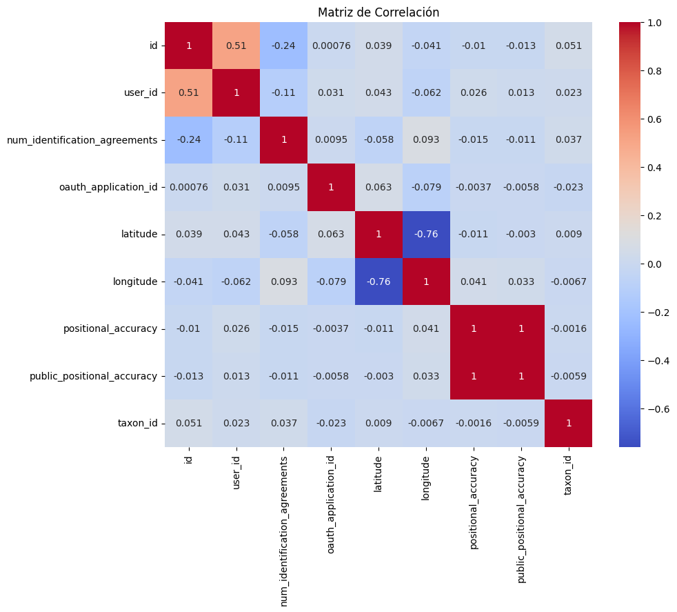

```python
# 1. Filtrar solo las columnas numéricas
numeric_df = df_cleaned.select_dtypes(include=['float64', 'int64'])

# 2. Comprobar correlación solo en columnas numéricas
correlation = numeric_df.corr()

# 3. Visualizar la matriz de correlación
import seaborn as sns
import matplotlib.pyplot as plt

plt.figure(figsize=(10, 8))
sns.heatmap(correlation, annot=True, cmap='coolwarm')
plt.title('Matriz de Correlación')
plt.show()
```

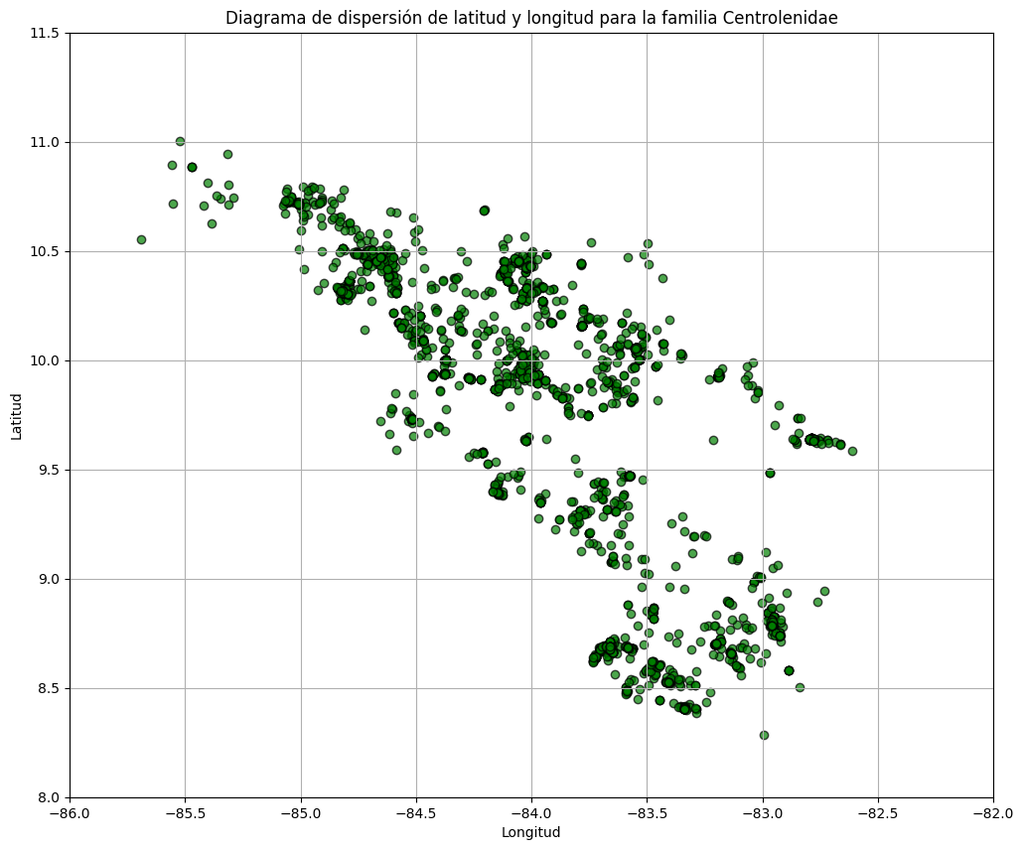

```python
#Realizamos un diagrama de dispersión para explorar la distribución geográfica de las observaciones de Centrolenidae

x = df["longitude"]
y = df["latitude"]

plt.figure(figsize=(12, 10))
plt.scatter(x, y, alpha=0.7, c='green', edgecolor='k')  # Color verde para diferenciar
plt.title('Diagrama de dispersión de latitud y longitud para la familia ' + "Centrolenidae")
plt.xlabel('Longitud')
plt.ylabel('Latitud')
plt.grid(True)
plt.xlim([-86, -82])
plt.ylim([8, 11.5])
plt.show()
```

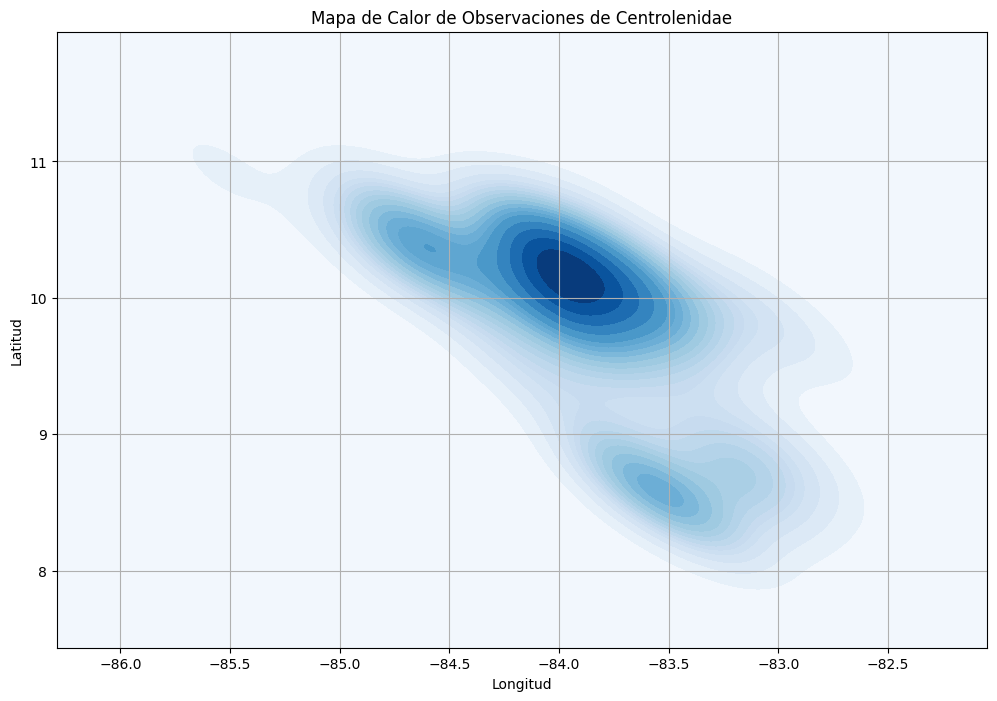

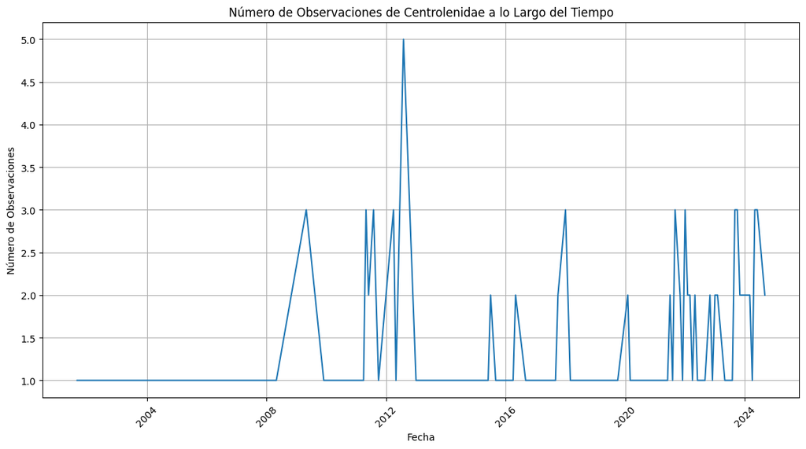

```python
# Formato datetime
df['observed_on'] = pd.to_datetime(df['observed_on_string'], errors='coerce')

# Filtra los datos para eliminar las filas con fechas no válidas
df = df.dropna(subset=['observed_on'])

# 1. Visualización de la Distribución Espacial mediante un Mapa de Calor

plt.figure(figsize=(12, 8))
sns.kdeplot(data=df, x='longitude', y='latitude', cmap='Blues', fill=True, thresh=0, levels=20)
plt.title('Mapa de Calor de Observaciones de Centrolenidae')
plt.xlabel('Longitud')
plt.ylabel('Latitud')
plt.grid(True)
plt.show()

# 2. Distribución Temporal

# Extraer año y mes de la fecha
df['year'] = df['observed_on'].dt.year
df['month'] = df['observed_on'].dt.month

# Agrupar por año y mes para contar el número de observaciones
observations_per_month = df.groupby(['year', 'month']).size().reset_index(name='count')

# Crear una nueva columna de fecha para facilitar la gráfica
observations_per_month['date'] = pd.to_datetime(observations_per_month[['year', 'month']].assign(day=1))

# Gráfica de la distribución temporal
plt.figure(figsize=(14, 7))
sns.lineplot(data=observations_per_month, x='date', y='count')
plt.title('Número de Observaciones de Centrolenidae a lo Largo del Tiempo')
plt.xlabel('Fecha')
plt.ylabel('Número de Observaciones')
plt.xticks(rotation=45)
plt.grid(True)
plt.show()
```

```
Valores nulos por columna:
id                                  0
observed_on_string                  0
time_zone                           0
user_id                             0
user_login                          0
created_at                          0
updated_at                          0
quality_grade                       0
url                                 0
tag_list                         2515
description                      2328
num_identification_agreements       0
captive_cultivated                  0
oauth_application_id             1007
place_guess                        10
latitude                            0
longitude                           0
positional_accuracy               397
private_place_guess              2566
public_positional_accuracy        357
geoprivacy                       2419
taxon_geoprivacy                  424
coordinates_obscured                0
positioning_method               1810
species_guess                     229
scientific_name                     0
common_name                        50
iconic_taxon_name                   0
taxon_id                            0
dtype: int64
```

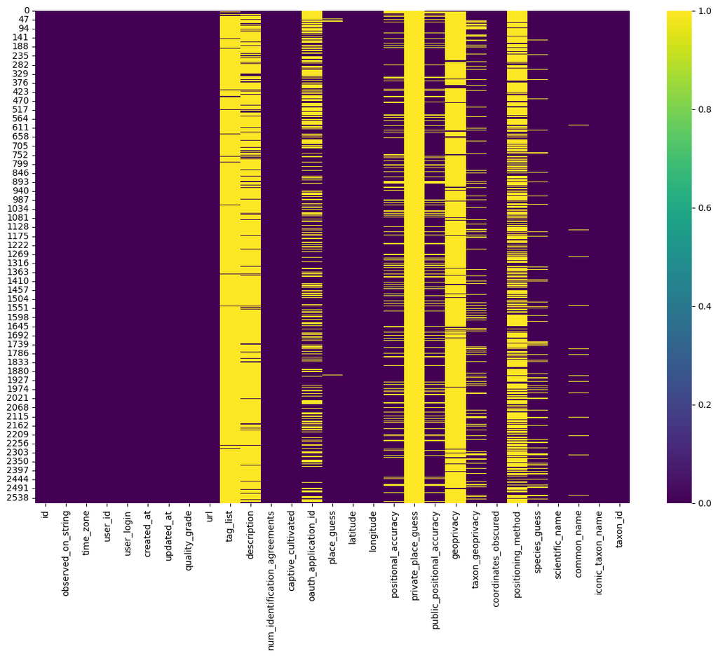

```python
# Figura 1. Realizamos un gráfico para observar la cantidad de datos nulos por columna del df
import seaborn as sns
import matplotlib.pyplot as plt

# Mostramos los valores nulos para cada columna
print("Valores nulos por columna:")
print(df.isnull().sum())

# Ajustar el tamaño de la figura dependiendo del número de columnas
plt.figure(figsize=(15, 10))

# Hacemos un mapa de calor con los valores nulos por columna
sns.heatmap(df.isnull(), cbar=True, cmap='viridis')

# Mostrar el gráfico
plt.show()
```

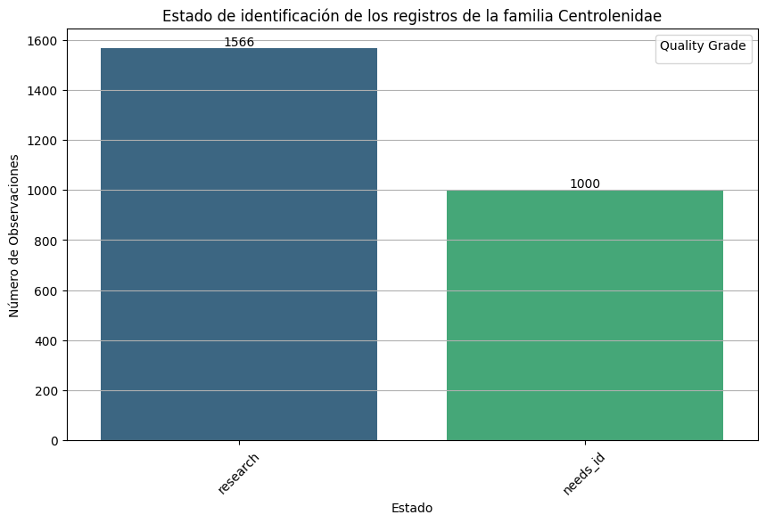

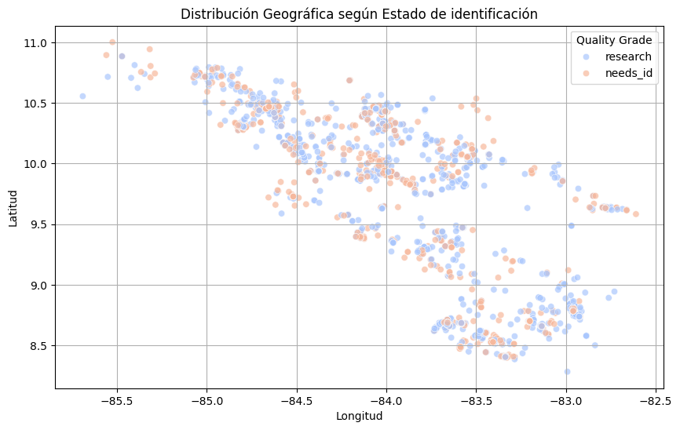

```python
# Cargar el archivo CSV en un DataFrame de pandas
df = pd.read_csv('Centrolenidae.csv')

# Análisis de la columna 'quality_grade' con conteo de ocurrencias
grouped_data = df['quality_grade'].value_counts().reset_index()
grouped_data.columns = ['quality_grade', 'count']

# Gráfico de barras para visualizar el estado de identificación
plt.figure(figsize=(10, 6))
barplot = sns.barplot(x='quality_grade', y='count', data=grouped_data, palette='viridis', hue='quality_grade')

# Añadir etiquetas a las barras
for p in barplot.patches:
    barplot.annotate(f'{int(p.get_height())}', (p.get_x() + p.get_width() / 2., p.get_height()),
                     ha='center', va='bottom')

plt.title('Estado de identificación de los registros de la familia Centrolenidae')
plt.xlabel('Estado')
plt.ylabel('Número de Observaciones')
plt.xticks(rotation=45)
plt.grid(axis='y')

# Quitar la leyenda si no es necesaria
plt.legend([], [], title='Quality Grade')
plt.show()

# Gráfico de dispersión mostrando la distribución geográfica según 'Estado de identificación'
plt.figure(figsize=(10, 6))
scatterplot = sns.scatterplot(x='longitude', y='latitude', hue='quality_grade', data=df, palette='coolwarm', alpha=0.7)
plt.title('Distribución Geográfica según Estado de identificación')
plt.xlabel('Longitud')
plt.ylabel('Latitud')
plt.legend(title='Quality Grade', loc='upper right')
plt.grid()
plt.show()
```

Descripción de los resultados obtenidos

Los análisis realizados sobre la familia Centrolenidae han revelado resultados significativos que aportan una comprensión más profunda de su distribución geográfica, estado de identificación y evolución temporal en cuanto a las observaciones registradas.

En primer lugar, se identificaron un total de 2,566 registros de esta familia de anfibios. De estos, 1,566 registros están clasificados como "research," lo que indica que han sido objeto de investigación y validación. Sin embargo, se destaca que 1,000 registros se encuentran en la categoría "needs_id," lo que señala la necesidad de esfuerzos adicionales para completar la identificación de estas especies. Este hallazgo sugiere que, aunque se ha avanzado en la investigación, todavía existen lagunas que deben ser abordadas para asegurar la precisión y la integridad de los datos recopilados.

Además, la matriz de correlación proporcionó información valiosa sobre las relaciones entre variables geográficas y de identificación. Se identificaron correlaciones fuertes, como la relación inversa entre la latitud y la longitud, y una correlación positiva notable entre las precisiones posicionales. Sin embargo, la mayoría de las demás variables mostraron correlaciones débiles o nulas, lo que sugiere que no todas las características están interconectadas.

La distribución geográfica de los registros muestra una clara concentración en determinadas regiones. El diagrama de dispersión revela que los puntos de observación se agrupan en áreas específicas, lo que podría estar relacionado con factores ambientales que determinan la disponibilidad de hábitats adecuados para esta familia. Sin embargo, es importante mencionar que, para una representación más efectiva de los avistamientos, el conjunto de datos debería delimitarse por provincias. Esta clasificación facilitaría la creación de gráficos más precisos y permitiría una mejor visualización de la distribución de los registros, ya que actualmente, al ser registrados por lugares sin una delimitación clara, se dificulta su análisis y representación gráfica.

Un análisis más detallado de la densidad de observaciones se presenta en el mapa de calor, que proporciona una representación visual clara de las áreas con mayor concentración de registros. Los tonos más oscuros en el mapa indican una alta densidad de observaciones, mientras que las áreas en blanco muestran ubicaciones sin registros. Este patrón de distribución es crucial, ya que permite identificar zonas que podrían ser menos exploradas o menos favorables para la familia Centrolenidae. De esta manera, se pueden orientar futuras investigaciones y esfuerzos de conservación hacia áreas prioritarias que requieren atención.

Conclusiones

Los resultados obtenidos a lo largo de este trabajo destacan varios aspectos importantes sobre la familia Centrolenidae en Costa Ricaa. En primer lugar, se ha identificado una cantidad significativa de registros, de los cuales un 39% aún requieren una identificación más precisa. Esto subraya la necesidad de continuar con los esfuerzos de validación y clasificación de especies, ya que mejorar la calidad y utilidad de los datos disponibles es fundamental para las investigaciones futuras y la conservación de estas especies.

La matriz de correlación mostró una fuerte correlación negativa entre la latitud y la longitud, lo cual es lógico dado que representan coordenadas geográficas en direcciones opuestas. Además, se observó una correlación muy fuerte entre la precisión posicional y la precisión posicional pública, indicando que la calidad de los datos geográficos es consistente. Las correlaciones débiles o nulas entre la mayoría de las otras variables sugieren la necesidad de investigar más a fondo otras influencias externas que podrían afectar estas relaciones.

La distribución geográfica de los registros revela una clara concentración en determinadas regiones, lo que sugiere que factores ambientales y tipos de hábitat juegan un papel crucial en la presencia de estas especies. En este sentido, es necesario llevar a cabo una delimitación de los avistamientos por provincias, ya que esta medida permitirá un análisis más efectivo y una representación gráfica más precisa de la distribución geográfica de los registros.

Asimismo, el análisis de los datos mediante el mapa de calor ha evidenciado áreas con alta densidad de registros. Esta información es vital para dirigir los esfuerzos de conservación hacia las zonas que requieren atención prioritaria y para desarrollar estrategias de manejo adecuadas que protejan a estas especies en sus hábitats naturales.

Referencias Bibliograficas

Costa Rican Amphibian Research Center. (s.f). Glass Frogs / Ranas de Vidrio. https://cramphibian.com/glass-frogs-ranas-de-vidrio/#:~:text=Ranas%20de%20Vidrio%20de%20Costa,de%20de%20Argentina%20y%20Bolivia.

Fisher, A. (2023). Cómo vive la rana de cristal, la especie única de anfibio que está perdiendo su hábitat en América Latina. National Geographic En Español. https://www.ngenespanol.com/animales/rana-de-cristal/

Forti, L. R., & Szabo, J. K. (2023). The iNaturalist platform as a source of data to study amphibians in Brazil. Anais da Academia Brasileira de Ciências, 95, e20220828.

Heberling, J. M., Miller, J. T., Noesgaard, D., Weingart, S. B., & Schigel, D. (2021). Data integration enables global biodiversity synthesis. Proceedings of the National Academy of Sciences, 118(6), e2018093118.

Rivera, M. (2022).Ranas de cristal. Rev. Acad. Colomb. Cienc. Ex. Fis. Nat. 46(179):585-586, abril-junio de 2022. doi: https://doi.org/10.18257/raccefyn.1714

Romero, R. (2023). ¿Qué tanto sabes de las ranas de cristal? | La trivia de Mongabay Latam. Noticias Ambientales. https://es.mongabay.com/2023/05/que-tanto-sabes-de-ranas-de-cristal-trivia/#:~:text=Las%20ranas%20de%20cristal%20son,un%20impacto%20en%20sus%20poblaciones.

Soberón, J., & Peterson, T. (2004). Biodiversity informatics: managing and applying primary biodiversity data. Philosophical Transactions of the Royal Society of London. Series B: Biological Sciences, 359(1444), 689-698.

Torres, N. (2019). Prpyecto de conservación de anfibios y uso sostenible de los recursos genéticos. Ministerio del Ambiente. https://www.amphibianark.org/wp-content/uploads/2021/11/Reproduccion-de-Atelopus-nanay.pdf

Zhang, J. (2017). Biodiversity science and macroecology in the era of big data. Biodiversity Science, 25(4), 355-363.